# IODS course project

## The tea dataset

We’ll move on to the tea dataset from Factominer. Let’s explore the data.

```r
library(FactoMineR);library(tidyr)
data(tea)

glimpse(tea)
```

```
## Rows: 300
## Columns: 36
## $ breakfast        <fct> breakfast, breakfast, Not.breakfast, Not.breakfast, …
## $ tea.time         <fct> Not.tea time, Not.tea time, tea time, Not.tea time, …
## $ evening          <fct> Not.evening, Not.evening, evening, Not.evening, even…
## $ lunch            <fct> Not.lunch, Not.lunch, Not.lunch, Not.lunch, Not.lunc…
## $ dinner           <fct> Not.dinner, Not.dinner, dinner, dinner, Not.dinner, …
## $ always           <fct> Not.always, Not.always, Not.always, Not.always, alwa…
## $ home             <fct> home, home, home, home, home, home, home, home, home…
## $ work             <fct> Not.work, Not.work, work, Not.work, Not.work, Not.wo…
## $ tearoom          <fct> Not.tearoom, Not.tearoom, Not.tearoom, Not.tearoom, …
## $ friends          <fct> Not.friends, Not.friends, friends, Not.friends, Not.…
## $ resto            <fct> Not.resto, Not.resto, resto, Not.resto, Not.resto, N…
## $ pub              <fct> Not.pub, Not.pub, Not.pub, Not.pub, Not.pub, Not.pub…
## $ Tea              <fct> black, black, Earl Grey, Earl Grey, Earl Grey, Earl …
```

[output cut: 23 more lines]

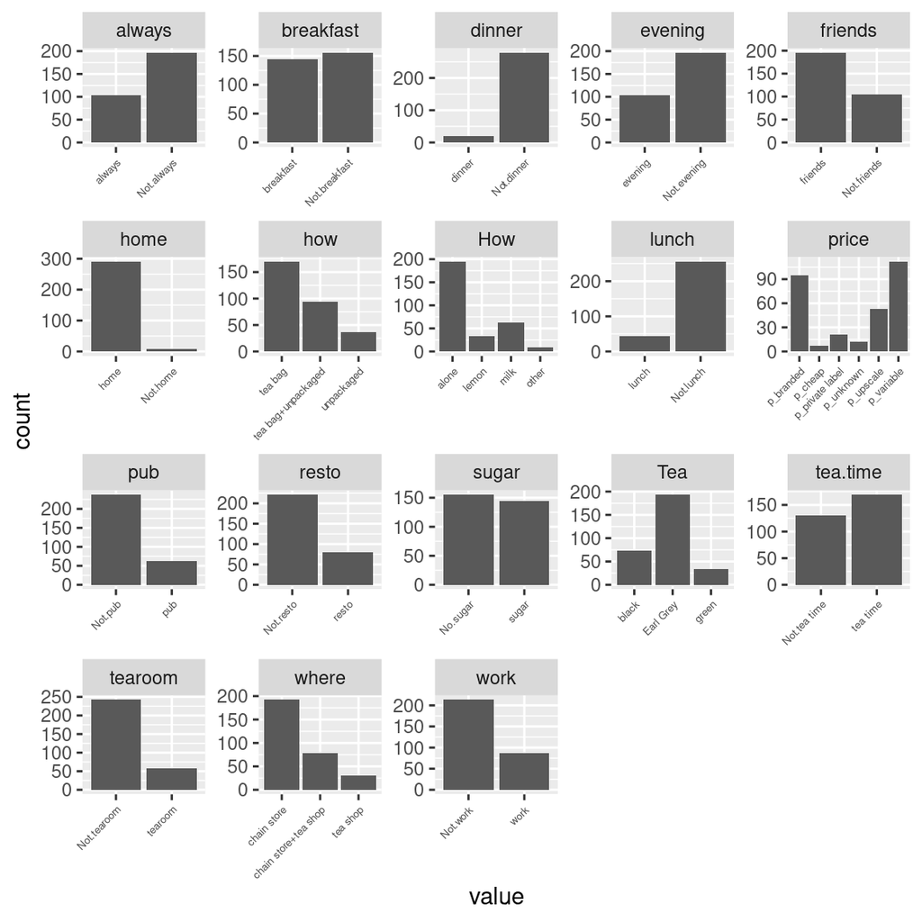

```r
#First 18 variables
gather(tea[,1:18]) %>% ggplot(aes(value)) + facet_wrap("key", scales = "free") + geom_bar() + theme(axis.text.x = element_text(angle = 45, hjust = 1, size = 5))
```

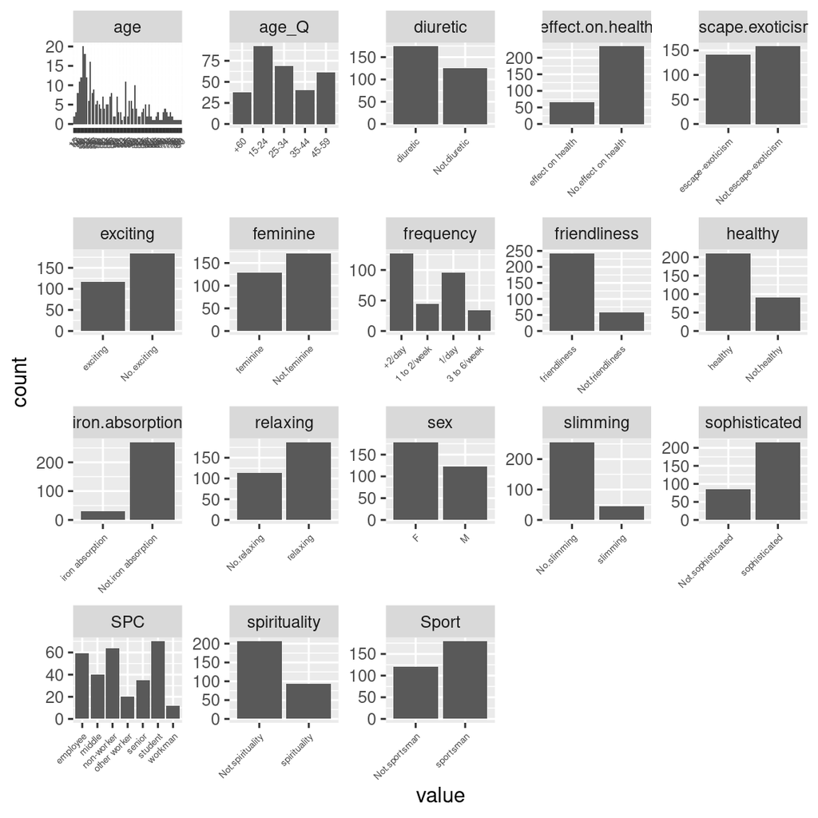

```r
# Last 18 variables
gather(tea[,19:36]) %>% ggplot(aes(value)) + facet_wrap("key", scales = "free") + geom_bar() + theme(axis.text.x = element_text(angle = 45, hjust = 1, size = 5))
```

Most of the variables are factors, with one integer variable (age). The dataset was construced by asking 300 individuals (rows) how they drink tea, how they perceive their products along with personal questions (altogether 36 questions, columns).

We’ll plot the data with MCA. First, we’ll subset a bit to make the analysis a bit easier.

```r
# Column names to keep in the dataset
keep_columns <- c("Tea", "How", "how", "sugar", "where", "age_Q")
tea_time <- dplyr::select(tea, one_of(keep_columns))

mca <- MCA(tea_time, graph = FALSE)
summary(mca)
```

```
##
## Call:
## MCA(X = tea_time, graph = FALSE)
##
##
## Eigenvalues
##                        Dim.1   Dim.2   Dim.3   Dim.4   Dim.5   Dim.6   Dim.7
## Variance               0.313   0.266   0.249   0.205   0.184   0.175   0.168
## % of var.             13.434  11.404  10.689   8.791   7.883   7.511   7.218
## Cumulative % of var.  13.434  24.838  35.527  44.318  52.201  59.712  66.930
##                        Dim.8   Dim.9  Dim.10  Dim.11  Dim.12  Dim.13  Dim.14
## Variance               0.147   0.141   0.135   0.119   0.101   0.072   0.056
## % of var.              6.302   6.051   5.787   5.086   4.348   3.094   2.403
## Cumulative % of var.  73.231  79.282  85.069  90.155  94.503  97.597 100.000
##
## Individuals (the 10 first)
##                       Dim.1    ctr   cos2    Dim.2    ctr   cos2    Dim.3
## 1                  | -0.068  0.005  0.002 |  0.048  0.003  0.001 | -0.471
## 2                  |  0.142  0.021  0.009 |  0.089  0.010  0.004 | -1.069
## 3                  | -0.199  0.042  0.033 | -0.254  0.081  0.053 | -0.600
## 4                  | -0.798  0.678  0.665 | -0.240  0.072  0.060 |  0.064
## 5                  | -0.199  0.042  0.033 | -0.254  0.081  0.053 | -0.600
## 6                  | -0.582  0.360  0.361 | -0.167  0.035  0.030 | -0.235
## 7                  | -0.190  0.039  0.022 | -0.036  0.002  0.001 | -0.411
## 8                  |  0.150  0.024  0.009 |  0.307  0.118  0.036 | -0.880
## 9                  |  0.268  0.076  0.026 |  0.900  1.016  0.290 |  0.175
## 10                 |  0.605  0.390  0.137 |  0.870  0.948  0.282 | -0.073
##                       ctr   cos2
## 1                   0.296  0.106 |
## 2                   1.527  0.527 |
## 3                   0.481  0.297 |
## 4                   0.005  0.004 |
## 5                   0.481  0.297 |
## 6                   0.074  0.059 |
## 7                   0.226  0.103 |
## 8                   1.035  0.298 |
## 9                   0.041  0.011 |
## 10                  0.007  0.002 |
##
## Categories (the 10 first)
```

[output cut: 16 more lines]

```
## lemon              |  1.264 11.746  0.197  7.685 |
## milk               | -0.379  2.011  0.038 -3.375 |
## other              | -0.957  1.836  0.028 -2.910 |
## tea bag            | -0.436  7.208  0.249 -8.627 |
## tea bag+unpackaged |  0.663  9.193  0.200  7.740 |
## unpackaged         |  0.330  0.873  0.015  2.107 |
##
## Categorical variables (eta2)
##                      Dim.1 Dim.2 Dim.3
## Tea                | 0.275 0.154 0.216 |
## How                | 0.060 0.295 0.235 |
## how                | 0.484 0.334 0.259 |
## sugar              | 0.132 0.013 0.200 |
## where              | 0.528 0.632 0.233 |
## age_Q              | 0.402 0.169 0.354 |
```

There are altogether 14 dimensions. The first three dimensions retain 10-13 % of variance each. We only see the first 10 individuals (rows) and their contribution to the dimensiona (ctr) as well as squared correlations to the dimension (cos2). Same with the first 10 categories and their relationship to the first dimension. Lastly, we have the categorical variables and their squared correlation to each dimension. If these values are close to 1, there is a strong link with the variable and the dimension. We see the variable “where” has the strongest link to dimension 1, with “how” being quite close as a second and “age_Q” as a third. Additionally, the variable “where” has the strongest relationship with dimension 2 and the second “How” is has a stronger link with dimension 2 compared to dimension 1.

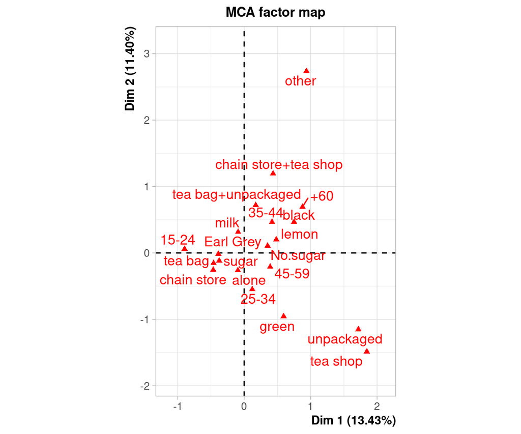

MCA plot of the subsetted tea data. The closer the variables, the more similar they are. Buying tea from specialised tea shops is similar to consuming unpackaged tea, which makes sense, since tea shops usually sell unpackaged tea. They both have a strong relationship to dimension 1. Green tea consumers are probably more likely to buy from unpackaged tea from tea shops. Tea consuption is different in the age groups. For example, 15-24 year olds are quite close to tea bag, Earl Grey and chain stores. Presumably chain stores mostly sell tea bags (instead of unpackaged) and Earl Grey is a popular option. Also, chain store Early Grey tea bags are likely cheap, and 15-24 year olds usually don’t have that high of an income. 60+ year olds are more likely to drink black tea. Drinking tea as it is (=alone) or with sugar are close to the centre, which indicates that consuming tea either of these ways vary enough between all subjects for those not to be pulled towards a certain dimension too strongly. No sugar, milk and lemon are a bit farther from the centre, but still quite close. Consuming tea in an other way is far from other categories, so they are a certain group of people.

```r
# Plot function for MCA, hide individual observations
plot.MCA(mca, invisible = c("ind"))
```